# Frequentist Weighted Linear Regression

- Show All Code
- Hide All Code
- View Source

Author

Ananda Biswas

Published

November 3, 2026

## Required Libraries

**Show/Hide Code**

```r
library(openxlsx)

library(wCorr)
library(DescTools)

library(gt)
library(tidyverse)
```

## Loading Data

**Show/Hide Code**

```r
df1 <- read.xlsx(data.path, sheet = 1)

df2 <- df1[1:14, ]
```

## Initial Sanity Checks

**Show/Hide Code**

```r
str(df2)
```

```
'data.frame':   14 obs. of  11 variables:
 $ Study            : chr  "Study.1" "Study.2" "Study.3" "Study.4" ...
 $ Sample.n1        : num  133 95 128 272 107 152 44 133 135 90 ...
 $ Sample.n2        : num  136 95 124 264 112 154 44 148 136 88 ...
 $ Follow-.up.months: num  97 72 71 80 199 78 59 156 74 145 ...
 $ HR.OS            : num  0.84 0.51 0.6 0.82 0.93 0.85 0.55 0.85 0.98 0.74 ...
 $ OS.ln.HR         : num  -0.17 -0.67 -0.51 -0.2 -0.07 -0.16 -0.6 -0.16 -0.02 -0.3 ...
 $ OS.se            : num  0.16 0.29 0.34 0.22 0.15 0.15 0.26 0.15 0.17 0.17 ...
 $ HR.DFS           : num  0.83 0.49 0.62 0.79 0.88 0.76 0.55 0.87 0.9 0.73 ...
 $ DFS.ln.HR        : num  -0.19 -0.71 -0.48 -0.24 -0.13 -0.27 -0.6 -0.14 -0.11 -0.31 ...
 $ DFS.se           : num  0.16 0.27 0.32 0.21 0.15 0.15 0.25 0.15 0.16 0.17 ...
 $ Non.prop         : chr  "0" "0" "0" "0" ...
```

**Show/Hide Code**

```r
dim(df2)
```

```
[1] 14 11
```

Snapshot of Gastric Cancer Data

| Study | Sample.n1 | Sample.n2 | Follow-.up.months | HR.OS | OS.ln.HR | OS.se | HR.DFS | DFS.ln.HR | DFS.se | Non.prop |
| --- | --- | --- | --- | --- | --- | --- | --- | --- | --- | --- |
| Study.1 | 133 | 136 | 97 | 0.84 | -0.17 | 0.16 | 0.83 | -0.19 | 0.16 | 0 |
| Study.2 | 95 | 95 | 72 | 0.51 | -0.67 | 0.29 | 0.49 | -0.71 | 0.27 | 0 |
| Study.3 | 128 | 124 | 71 | 0.60 | -0.51 | 0.34 | 0.62 | -0.48 | 0.32 | 0 |
| Study.4 | 272 | 264 | 80 | 0.82 | -0.20 | 0.22 | 0.79 | -0.24 | 0.21 | 0 |
| Study.5 | 107 | 112 | 199 | 0.93 | -0.07 | 0.15 | 0.88 | -0.13 | 0.15 | 0 |
| Study.6 | 152 | 154 | 78 | 0.85 | -0.16 | 0.15 | 0.76 | -0.27 | 0.15 | 0 |

## Generating Treatment Effect on Surrogate Endpoint in New Trials

**Show/Hide Code**

```r
range(df2$HR.DFS)
```

```
[1] 0.49 1.05
```

**Show/Hide Code**

```r
# Suppose 1000 new trials reporting TE on surrogate endpoint only
new.data <- data.frame(DFS.ln.HR = log(seq(0.45, 1.2, length = 1000)))
```

## Some Derived Quantities

The weights used in this analysis were the inverse variance $1/{\text{SE}^2}$ of the log HR of OS.

**Show/Hide Code**

```r
df2$weight <- 1 / (df2$OS.se)^2
```

The weighted correlation coefficient $(\rho)$ was estimated using the Pearson weighted correlation of the target and the surrogate endpoints.

**Show/Hide Code**

```r
rho <- weightedCorr(df2$OS.ln.HR, df2$DFS.ln.HR,
             method = "Pearson",
             weights = 1 / df2$OS.se^2)
rho
```

```
[1] 0.9697118
```

Confidence intervals around Pearson $\rho$ are not symmetrical. Therefore, a Fisher’s $z-$transformation was applied to estimate the $95\%$ confidence intervals, which is conducted using the `CorCI()` function in the `DescTools` package.

**Show/Hide Code**

```r
effective.n <- sum(df2$weight)^2 / sum(df2$weight^2)
effective.n <- round(effective.n, 1)

effective.n
```

```
[1] 12.1
```

**Show/Hide Code**

```r
CorCI(rho = rho,
      n = effective.n,
      conf.level = 0.95, alternative = "two.sided")
```

```
      cor    lwr.ci    upr.ci
0.9697118 0.8932380 0.9916489
```

## Model

The weighted linear regression (WLR) model is given by

$$\theta_i = \alpha + \beta\gamma_i + \varepsilon_i,
\qquad i = 1,\ldots,n,$$

where

$$\varepsilon_i \sim
N\left(0,\sigma_{\theta_i}^2\right);
\qquad
w_i = \dfrac{1}{\sigma_{\theta_i}^2}.$$

The parameters $\alpha$ and $\beta$ are estimated by minimizing the weighted sum of squared residuals:

$$\underset{\alpha,\beta}{\operatorname{minimize}}
\sum_{i=1}^{n}
w_i
\left(
\theta_i-\alpha-\beta\gamma_i
\right)^2.$$
Here:

- $\theta_i$ is the treatment effect on the final endpoint in study $i$;
- $\gamma_i$ is the treatment effect on the surrogate endpoint in study $i$;
- $\alpha$ is the intercept;
- $\beta$ is the regression coefficient measuring the association between treatment effects on the surrogate and final endpoints; and
- $w_i$ is the weight assigned to study $i$.

## Model Fitting

Frequentist weighted linear regression is arguably the *simplest* approach to a surrogate analysis. A weighted linear regression model was used to relate the target endpoint (log HRs of OS) to the surrogate endpoint (log HRs of DFS). The data were *weighted* by the inverse of the variance of the log HRs of the target variable.

**Show/Hide Code**

```r
fit <- lm(OS.ln.HR ~ DFS.ln.HR, weights = weight, data = df2)
summary(fit)
```

```
Call:
lm(formula = OS.ln.HR ~ DFS.ln.HR, data = df2, weights = weight)

Weighted Residuals:
     Min       1Q   Median       3Q      Max
-0.42120 -0.16294  0.01602  0.10695  0.46604

Coefficients:
            Estimate Std. Error t value Pr(>|t|)
(Intercept)  0.04650    0.01848   2.516   0.0271 *
DFS.ln.HR    1.02374    0.07444  13.753 1.04e-08 ***
---
Signif. codes:  0 '***' 0.001 '**' 0.01 '*' 0.05 '.' 0.1 ' ' 1

Residual standard error: 0.2388 on 12 degrees of freedom
Multiple R-squared:  0.9403,    Adjusted R-squared:  0.9354
F-statistic: 189.1 on 1 and 12 DF,  p-value: 1.044e-08
```

**Show/Hide Code**

```r
sqrt(summary(fit)$r.squared)
```

```
[1] 0.9697118
```

## Prediction of TE on Clinical Outcome in New Trials

### Confidence Intervals

**Show/Hide Code**

```r
wlr.ci <- data.frame(predict(fit, newdata = new.data, interval = "confidence"))

head(wlr.ci)
```

```
         fit        lwr        upr
1 -0.7709615 -0.8725780 -0.6693450
2 -0.7692550 -0.8706099 -0.6679001
3 -0.7675513 -0.8686450 -0.6664576
4 -0.7658505 -0.8666834 -0.6650175
5 -0.7641524 -0.8647252 -0.6635797
6 -0.7624572 -0.8627702 -0.6621442
```

### Prediction Intervals

**Show/Hide Code**

```r
wlr.pi <- data.frame(predict(fit, newdata = new.data, interval = "prediction",
                  weight = 1 / (mean(df2$OS.se)^2) ))

head(wlr.pi)
```

```
         fit        lwr        upr
1 -0.7709615 -0.9164077 -0.6255154
2 -0.7692550 -0.9145184 -0.6239915
3 -0.7675513 -0.9126326 -0.6224700
4 -0.7658505 -0.9107502 -0.6209507
5 -0.7641524 -0.9088713 -0.6194336
6 -0.7624572 -0.9069956 -0.6179188
```

## Trial-level Association Plot

**Show/Hide Code**

```r
wlr.pred.df <- data.frame(HR.OS = exp(wlr.ci[,1]),
                        HR.DFS = exp(new.data$DFS.ln.HR),
                        lower.ci = exp(wlr.ci[,2]),
                        upper.ci = exp(wlr.ci[,3]),
                        lower.pi = exp(wlr.pi[,2]),
                        upper.pi = exp(wlr.pi[,3]))
```

**Show/Hide Code**

```r
wlr.association.plot <- ggplot(df2, aes(x = HR.DFS, y = HR.OS)) +
  geom_ribbon(aes(x = HR.DFS, ymin = lower.ci, ymax = upper.ci), data = wlr.pred.df, stat = 'identity', fill = "steelblue", alpha = 0.5) +
  geom_ribbon(aes(x = HR.DFS, ymin = lower.pi, ymax = upper.pi), data = wlr.pred.df, stat = 'identity', fill = "lightblue", alpha = 0.4) +
  scale_x_continuous(trans = "log",
                     limits = c(0.45, 1.2),
                     breaks=c(0.4,0.5,0.6,0.7,0.8,0.9,1,1.1),
                     expand = c(0.01, 0.01)) +
  scale_y_continuous(trans = "log",
                     limits=c(0.35, 1.5),
                     breaks=c(0.1,0.2,0.3,0.4,0.5,0.7,1,1.2,1.5,2,3),
                     expand = c(0.01, 0.01)) +
  geom_smooth(aes(x = HR.DFS, y = HR.OS), data = wlr.pred.df, stat = 'identity') +
  geom_point(aes(x = HR.DFS, y = HR.OS, size = weight),
             col = "gray30", shape = 21, fill = "orange") +
  geom_hline(yintercept = 1, linetype = 'dashed') +
  xlab("Disease-free survival hazard ratio (log scale)")+
  ylab(paste("Overall survival hazard ratio" , "\n", "\U00B1", "95% confidence and prediction intervals (log scale)")) +
  ggtitle("Weighted Linear Regression") +
  theme_bw() +
  scale_colour_hue("trial") +
  theme(legend.position = "none")
```

**Show/Hide Code**

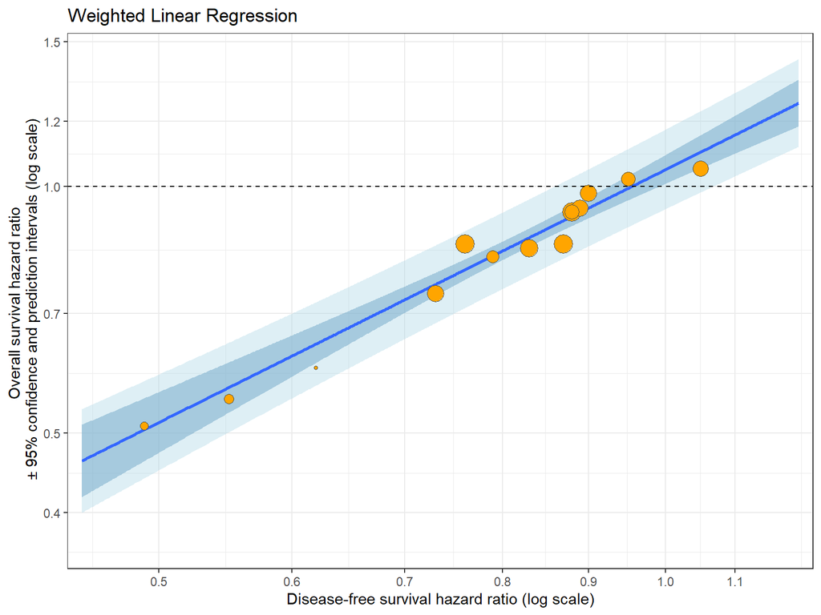

```r
wlr.association.plot
```

## Surrogate Threshold Effect

Surrogate Threshold Effect is defined as *the minimum treatment effect on the surrogate necessary to predict a nonzero effect on the true endpoint* in a future trial. $\log(HR) < 0$ implies a *beneficial* treatment effect. So STE was computed as the intersection of the upper $95\%$ prediction interval with the horizontal line for no treatment effect (i.e., in which the HR for OS equals $1$ or $\log(HR) = 0$).

**Show/Hide Code**

```r
candidate.HR.DFS <- wlr.pred.df %>%
  filter(upper.pi < 1) %>%
  pull(HR.DFS)

WLR.STE <- round(max(candidate.HR.DFS), digits = 3)

WLR.STE
```

```
[1] 0.86
```

## Leave-one-out Cross-validation

Leave-one-out cross-validation (LOOCV) is performed by selecting each trial in a data set in turns and using it as the validation set while using the rest $(n-1)$ of the trials as the training set. This is repeated $n$ times. For each iteration in the LOOCV procedure, models are ﬁtted to the training set, and the dependent variable of interest (target endpoint) is predicted on the basis of the explanatory variable(s) in the models (surrogate endpoint) in the validation set.

Two different criteria were used to assess the performance of each model for each iteration of the LOOCV. For each criterion, the median and range of the output values were used to assess model performance.

### Proportion of actual values from the validation set that lies within the 95% prediction interval from the training set

The steps are as follows:

- Leave out $i-$th study and train the model with remaining $n - 1$ studies.
- Obtain $95\%$ prediction interval for the treatment effect on target endpoint (OS) in the left-out trial, using its surrogate endpoint (DFS) treatment effect.
- Simulate $1000$ OS treatment effects based on normal distribution using the observed OS treatment effect and its standard error from the left-out trial.
- Calculate the proportion of the $1000$ simulated values falling within the prediction interval, $p_i$.
- Repeat these steps for all the studies, leaving out one at a time.
- Calculate $median(p_1, \ldots, p_n)$ and $range(p_1, \ldots, p_n)$.

**Show/Hide Code**

```r
n <- nrow(df2)

prop <- c()

absolute.difference <- c()
```

**Show/Hide Code**

```r
for(i in 1:n){
  df <- df2[-i,]

  fit <- lm(OS.ln.HR ~ DFS.ln.HR, weights = weight, data = df)

  new.data <- data.frame(DFS.ln.HR = df2$DFS.ln.HR[i])

  wlr.pi <- data.frame(predict(fit, newdata = new.data, interval = "prediction",
                               weight = 1 / (mean(df$OS.se)^2) ))

  # for criterion 1
  simulated.OS.ln.HR <- rnorm(1000, mean = df2$OS.ln.HR[i], sd = df2$OS.se[i])

  prop[i] <- mean((simulated.OS.ln.HR >= wlr.pi[,2] & simulated.OS.ln.HR <= wlr.pi[,3]))

  # for criterion 2
  absolute.difference[i] <- abs(wlr.pi$fit - df2$OS.ln.HR[i])
}
```

**Show/Hide Code**

```r
median.prop <- median(prop)
median.prop
```

```
[1] 0.441
```

**Show/Hide Code**

```r
range.prop <- range(prop)
range.prop
```

```
[1] 0.256 0.577
```

### Absolute difference between mean predicted value and actual value

The absolute difference between the actual log hazard ratio and the predicted log hazard ratio for OS for each trial left out will be recorded.

**Show/Hide Code**

```r
median.absolute.difference <- median(absolute.difference)
median.absolute.difference |> round(3)
```

```
[1] 0.031
```

**Show/Hide Code**

```r
range.absolute.difference <- range(absolute.difference)
range.absolute.difference |> round(3)
```

```
[1] 0.001 0.081
```